# Item_collaborative_filtering_recommender

Jack Hickey

2/5/2022

This is an item based collaborative recommendation system.

Michael Hahsler writing the recommenderlab description paper - The premise is that users who agreed on the rating for some items typically also agree on the rating for other items.

```r
library(recommenderlab)
```

```r
library(ggplot2)
library(data.table)
library(reshape2)
movies <- read.csv("movies.csv")
ratings <- read.csv("ratings.csv")

#check layout of the two datasets
head(movies)
```

```
##   movieId                              title
## 1       1                   Toy Story (1995)
## 2       2                     Jumanji (1995)
## 3       3            Grumpier Old Men (1995)
## 4       4           Waiting to Exhale (1995)
## 5       5 Father of the Bride Part II (1995)
## 6       6                        Heat (1995)
##                                        genres
## 1 Adventure|Animation|Children|Comedy|Fantasy
## 2                  Adventure|Children|Fantasy
## 3                              Comedy|Romance
## 4                        Comedy|Drama|Romance
## 5                                      Comedy
## 6                       Action|Crime|Thriller
```

```r
head(ratings)
```

```
##   userId movieId rating  timestamp
## 1      1      16    4.0 1217897793
## 2      1      24    1.5 1217895807
## 3      1      32    4.0 1217896246
## 4      1      47    4.0 1217896556
## 5      1      50    4.0 1217896523
## 6      1     110    4.0 1217896150
```

```r
str(movies)
```

```
## 'data.frame':    10329 obs. of  3 variables:
##  $ movieId: int  1 2 3 4 5 6 7 8 9 10 ...
##  $ title  : chr  "Toy Story (1995)" "Jumanji (1995)" "Grumpier Old Men (1995)" "Waiting to Exhale (1995)" ...
##  $ genres : chr  "Adventure|Animation|Children|Comedy|Fantasy" "Adventure|Children|Fantasy" "Comedy|Romance" "Comedy|Drama|Romance" ...
```

```r
str(ratings)
```

```
## 'data.frame':    105339 obs. of  4 variables:
##  $ userId   : int  1 1 1 1 1 1 1 1 1 1 ...
##  $ movieId  : int  16 24 32 47 50 110 150 161 165 204 ...
##  $ rating   : num  4 1.5 4 4 4 4 3 4 3 0.5 ...
##  $ timestamp: int  1217897793 1217895807 1217896246 1217896556 1217896523 1217896150 1217895940 1217897864 1217897135 1217895786 ...
```

```r
summary(movies)
```

```
##     movieId          title              genres
##  Min.   :     1   Length:10329       Length:10329
##  1st Qu.:  3240   Class :character   Class :character
##  Median :  7088   Mode  :character   Mode  :character
##  Mean   : 31924
##  3rd Qu.: 59900
##  Max.   :149532
```

```r
summary(ratings)
```

```
##      userId         movieId           rating        timestamp
##  Min.   :  1.0   Min.   :     1   Min.   :0.500   Min.   :8.286e+08
##  1st Qu.:192.0   1st Qu.:  1073   1st Qu.:3.000   1st Qu.:9.711e+08
##  Median :383.0   Median :  2497   Median :3.500   Median :1.115e+09
##  Mean   :364.9   Mean   : 13381   Mean   :3.517   Mean   :1.130e+09
##  3rd Qu.:557.0   3rd Qu.:  5991   3rd Qu.:4.000   3rd Qu.:1.275e+09
##  Max.   :668.0   Max.   :149532   Max.   :5.000   Max.   :1.452e+09
```

So both datasets possess the MovieId column. Noticeably the Genre column in `movies` is in character format which isn’t very helpful to us in terms of usability. Instead now we will transform this into a one-hot encoding that contains the 18 genres present in the dataset i.e transform the categorical variable into multiple variables set with a value of 1 or 0 (1 for when it is that particular genre and 0 if not). This is actually quite awkward due to the way that the Genre column is set up, using `|` as a seperator between genres in situations whereby some movies are comprised of multiple genres.

```r
library(data.table)
head(movies$genres)
```

```
## [1] "Adventure|Animation|Children|Comedy|Fantasy"
## [2] "Adventure|Children|Fantasy"
## [3] "Comedy|Romance"
## [4] "Comedy|Drama|Romance"
## [5] "Comedy"
## [6] "Action|Crime|Thriller"
```

```r
#create new dataframe just comprised of the genres column
movie_genres <- data.frame(movies$genres, stringsAsFactors = F)

#now split the column using the `|` delimiter
#note tstrsplit is the equivalent to: transpose(strsplit(x))
movie_genres2 <- data.frame(tstrsplit(movie_genres[,1], '[|]', type.convert = T), stringsAsFactors = F)
#movie_genres2 now contains columns with the separated genres for each movie, notably there are 10 so these are now labelled 1 to 10
colnames(movie_genres2) <- c(1:10)

#list all the possible genres
genres <- c("Action", "Adventure", "Animation", "Children", "Comedy", "Crime","Documentary", "Drama", "Fantasy", "Film-Noir", "Horror", "Musical", "Mystery","Romance", "Sci-Fi", "Thriller", "War", "Western")

#create empty matrix of 0's to fit the genres i.e 10330 rows (10329 rows of movies and 1 for the genre headings which will be coded in also) and 18 columns for the 18 possible genres
genre_mat <- matrix(0,10330,18)
genre_mat[1,] <- genres
colnames(genre_mat) <- genres

#nested for loops to scan through the genre matrix
for (index in 1:nrow(movie_genres2)) {
  for(col in 1:ncol(movie_genres2)) {
    genre_col = which(genre_mat[1,] == movie_genres2[index,col])
    genre_mat[index+1,genre_col] <- 1
  }
}

#remove the genre heading row in the dataframe
genre_mat1 <- as.data.frame(genre_mat[-1,], stringsAsFactors = F)

#the values are in character format so this needs to be changed to integers
for(col in 1:ncol(genre_mat1)) {
  genre_mat1[,col] <- as.integer(genre_mat1[,col])
}

head(genre_mat1)
```

```
##   Action Adventure Animation Children Comedy Crime Documentary Drama Fantasy
## 1      0         1         1        1      1     0           0     0       1
## 2      0         1         0        1      0     0           0     0       1
## 3      0         0         0        0      1     0           0     0       0
## 4      0         0         0        0      1     0           0     1       0
## 5      0         0         0        0      1     0           0     0       0
## 6      1         0         0        0      0     1           0     0       0
##   Film-Noir Horror Musical Mystery Romance Sci-Fi Thriller War Western
## 1         0      0       0       0       0      0        0   0       0
## 2         0      0       0       0       0      0        0   0       0
## 3         0      0       0       0       1      0        0   0       0
## 4         0      0       0       0       1      0        0   0       0
## 5         0      0       0       0       0      0        0   0       0
## 6         0      0       0       0       0      0        1   0       0
```

```r
str(genre_mat1)
```

```
## 'data.frame':    10329 obs. of  18 variables:
##  $ Action     : int  0 0 0 0 0 1 0 0 1 1 ...
##  $ Adventure  : int  1 1 0 0 0 0 0 1 0 1 ...
##  $ Animation  : int  1 0 0 0 0 0 0 0 0 0 ...
##  $ Children   : int  1 1 0 0 0 0 0 1 0 0 ...
##  $ Comedy     : int  1 0 1 1 1 0 1 0 0 0 ...
##  $ Crime      : int  0 0 0 0 0 1 0 0 0 0 ...
##  $ Documentary: int  0 0 0 0 0 0 0 0 0 0 ...
##  $ Drama      : int  0 0 0 1 0 0 0 0 0 0 ...
##  $ Fantasy    : int  1 1 0 0 0 0 0 0 0 0 ...
##  $ Film-Noir  : int  0 0 0 0 0 0 0 0 0 0 ...
##  $ Horror     : int  0 0 0 0 0 0 0 0 0 0 ...
##  $ Musical    : int  0 0 0 0 0 0 0 0 0 0 ...
##  $ Mystery    : int  0 0 0 0 0 0 0 0 0 0 ...
##  $ Romance    : int  0 0 1 1 0 0 1 0 0 0 ...
##  $ Sci-Fi     : int  0 0 0 0 0 0 0 0 0 0 ...
##  $ Thriller   : int  0 0 0 0 0 1 0 0 0 1 ...
##  $ War        : int  0 0 0 0 0 0 0 0 0 0 ...
##  $ Western    : int  0 0 0 0 0 0 0 0 0 0 ...
```

So now as we have preserved the order of the matrix throughout, thus the top row of our Genre Matrix is still the first element in the original movies dataset (i.e Toystory) these can be binded to form a search matrix of movies with their own genre allocations

```r
search_mat <- cbind(movies[,1:2], genre_mat1[])
head(search_mat)
```

```
##   movieId                              title Action Adventure Animation
## 1       1                   Toy Story (1995)      0         1         1
## 2       2                     Jumanji (1995)      0         1         0
## 3       3            Grumpier Old Men (1995)      0         0         0
## 4       4           Waiting to Exhale (1995)      0         0         0
## 5       5 Father of the Bride Part II (1995)      0         0         0
## 6       6                        Heat (1995)      1         0         0
##   Children Comedy Crime Documentary Drama Fantasy Film-Noir Horror Musical
## 1        1      1     0           0     0       1         0      0       0
## 2        1      0     0           0     0       1         0      0       0
## 3        0      1     0           0     0       0         0      0       0
## 4        0      1     0           0     1       0         0      0       0
## 5        0      1     0           0     0       0         0      0       0
## 6        0      0     1           0     0       0         0      0       0
##   Mystery Romance Sci-Fi Thriller War Western
## 1       0       0      0        0   0       0
## 2       0       0      0        0   0       0
## 3       0       1      0        0   0       0
## 4       0       1      0        0   0       0
## 5       0       0      0        0   0       0
## 6       0       0      0        1   0       0
```

```r
#dcast is a long to wide tool in data.table
rating_mat <- reshape2::dcast(ratings, userId~movieId, value.var = "rating", na.rm=F)
rating_mat <- as.matrix(rating_mat[,-1]) #get rid of UserId column

#now we transform this matrix into recommenderlab realRatingMatrix
rating_mat <- as(rating_mat, "realRatingMatrix")
rating_mat
```

```
## 668 x 10325 rating matrix of class 'realRatingMatrix' with 105339 ratings.
```

Now we will look at some of the parameters that may be put forward towards building recommendation systems

```r
recommend <- recommenderRegistry$get_entries(dataType = "realRatingMatrix")
names(recommend)
```

```
##  [1] "HYBRID_realRatingMatrix"       "ALS_realRatingMatrix"
##  [3] "ALS_implicit_realRatingMatrix" "IBCF_realRatingMatrix"
##  [5] "LIBMF_realRatingMatrix"        "POPULAR_realRatingMatrix"
##  [7] "RANDOM_realRatingMatrix"       "RERECOMMEND_realRatingMatrix"
##  [9] "SVD_realRatingMatrix"          "SVDF_realRatingMatrix"
## [11] "UBCF_realRatingMatrix"
```

```r
#obtain a description of some parameters
lapply(recommend, "[[", "description")
```

```
## $HYBRID_realRatingMatrix
## [1] "Hybrid recommender that aggegates several recommendation strategies using weighted averages."
##
## $ALS_realRatingMatrix
## [1] "Recommender for explicit ratings based on latent factors, calculated by alternating least squares algorithm."
##
## $ALS_implicit_realRatingMatrix
## [1] "Recommender for implicit data based on latent factors, calculated by alternating least squares algorithm."
##
## $IBCF_realRatingMatrix
## [1] "Recommender based on item-based collaborative filtering."
##
## $LIBMF_realRatingMatrix
## [1] "Matrix factorization with LIBMF via package recosystem (https://cran.r-project.org/web/packages/recosystem/vignettes/introduction.html)."
##
## $POPULAR_realRatingMatrix
## [1] "Recommender based on item popularity."
##
## $RANDOM_realRatingMatrix
## [1] "Produce random recommendations (real ratings)."
##
## $RERECOMMEND_realRatingMatrix
## [1] "Re-recommends highly rated items (real ratings)."
##
## $SVD_realRatingMatrix
## [1] "Recommender based on SVD approximation with column-mean imputation."
##
## $SVDF_realRatingMatrix
## [1] "Recommender based on Funk SVD with gradient descend (https://sifter.org/~simon/journal/20061211.html)."
##
## $UBCF_realRatingMatrix
## [1] "Recommender based on user-based collaborative filtering."
```

NOTE: $IBCF_realRatingMatrix [1] “Recommender based on item-based collaborative filtering.”

We are going to use this for this project

```r
#view the parameters of ICBF matrix
recommend$IBCF_realRatingMatrix$parameters
```

```
## $k
## [1] 30
##
## $method
## [1] "Cosine"
##
## $normalize
## [1] "center"
##
## $normalize_sim_matrix
## [1] FALSE
##
## $alpha
## [1] 0.5
##
## $na_as_zero
## [1] FALSE
```

The IBCF method for recommending movies relies on creating a relationship of similarity between users. Using the recommenderlab package we can compute similarities

Below we will create a matrix of users similarity to each other

```r
sim_mat <- similarity(rating_mat[1:4,],
                      method = "cosine",
                      which = "users")
as.matrix(sim_mat)
```

```
##           1         2         3         4
## 1 0.0000000 0.9760860 0.9641723 0.9914398
## 2 0.9760860 0.0000000 0.9925732 0.9374253
## 3 0.9641723 0.9925732 0.0000000 0.9888968
## 4 0.9914398 0.9374253 0.9888968 0.0000000
```

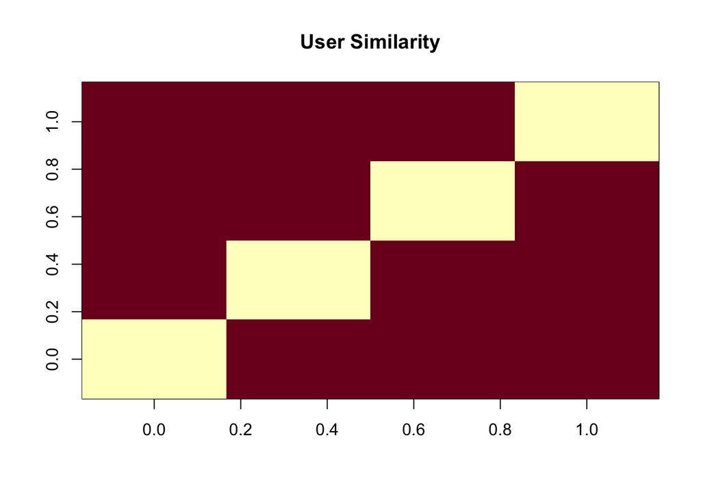

```r
image(as.matrix(sim_mat), main = "User Similarity")
```

now repeat the above chunk but for the movies

```r
movie_sim <- similarity(rating_mat[,1:4], method = "cosine", which = "items")

as.matrix(movie_sim)
```

```
##           1         2         3         4
## 1 0.0000000 0.9669732 0.9559341 0.9101276
## 2 0.9669732 0.0000000 0.9658757 0.9412416
## 3 0.9559341 0.9658757 0.0000000 0.9864877
## 4 0.9101276 0.9412416 0.9864877 0.0000000
```

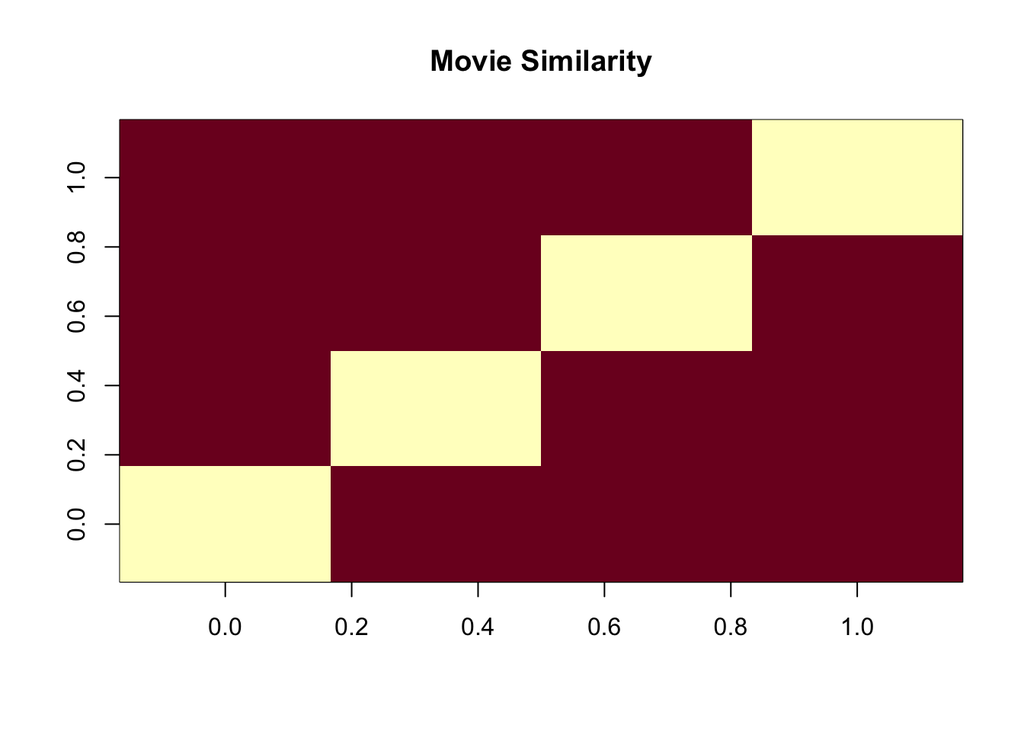

```r
image(as.matrix(movie_sim), main = "Movie Similarity")
```

```r
#look at the most unique ratings
rating_values <- as.vector(rating_mat@data)
unique(rating_values)
```

```
##  [1] 0.0 5.0 4.0 3.0 4.5 1.5 2.0 3.5 1.0 2.5 0.5
```

```r
#display the unique ratings here in a table
ratings_table <- table(rating_values)
ratings_table
```

```
## rating_values
##       0     0.5       1     1.5       2     2.5       3     3.5       4     4.5
## 6791761    1198    3258    1567    7943    5484   21729   12237   28880    8187
##       5
##   14856
```

some visualization exploration